# R Notebook

### 2

```r
mean(y)
```

```
[1] NA
```

```r
mean(y, na.rm = TRUE)
```

```
[1] 12.63907
```

```r
sum(y)
```

```
[1] NA
```

```r
sum(y, na.rm = TRUE)
```

```
[1] 4152200
```

Covariation is the tendency for the values of two or more variables to vary together in a related way.

The default appearance of geom_freqpoly() is not that useful for that sort of comparison because the height is given by the count. That means if one of the groups is much smaller than the others, it’s hard to see the differences in shape.

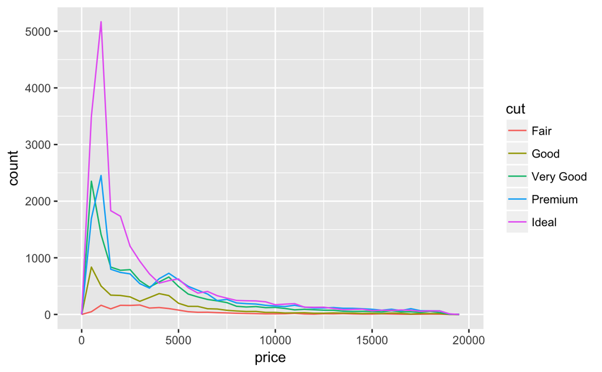

```r
ggplot(data = diamonds, mapping = aes(x = price)) +
  geom_freqpoly(mapping = aes(colour = cut), binwidth = 500)
```

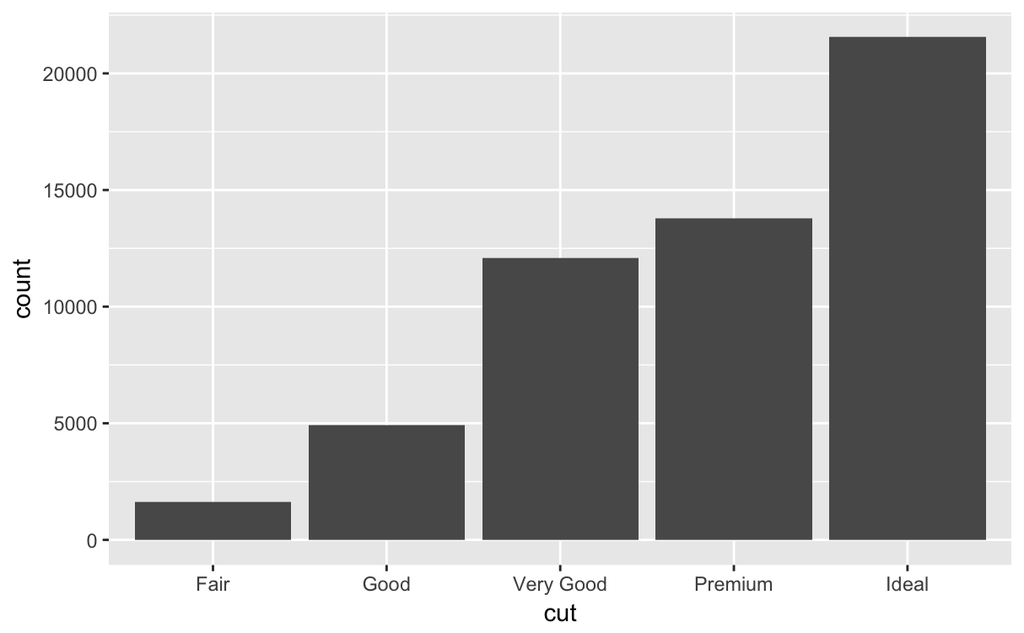

```r
#to see overall difference
ggplot(diamonds) +
  geom_bar(mapping = aes(x = cut))
```

To display density

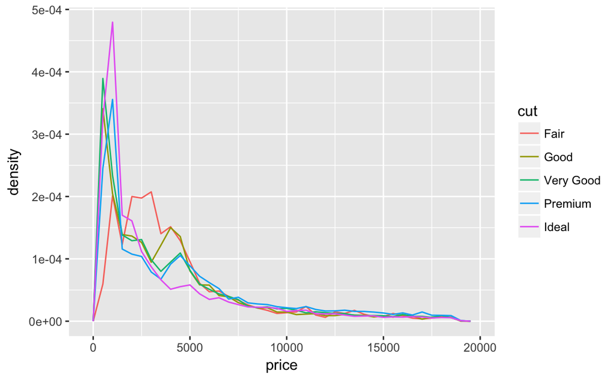

```r
ggplot(data = diamonds, mapping = aes(x = price, y = ..density..)) +
  geom_freqpoly(mapping = aes(colour = cut), binwidth = 500)
```

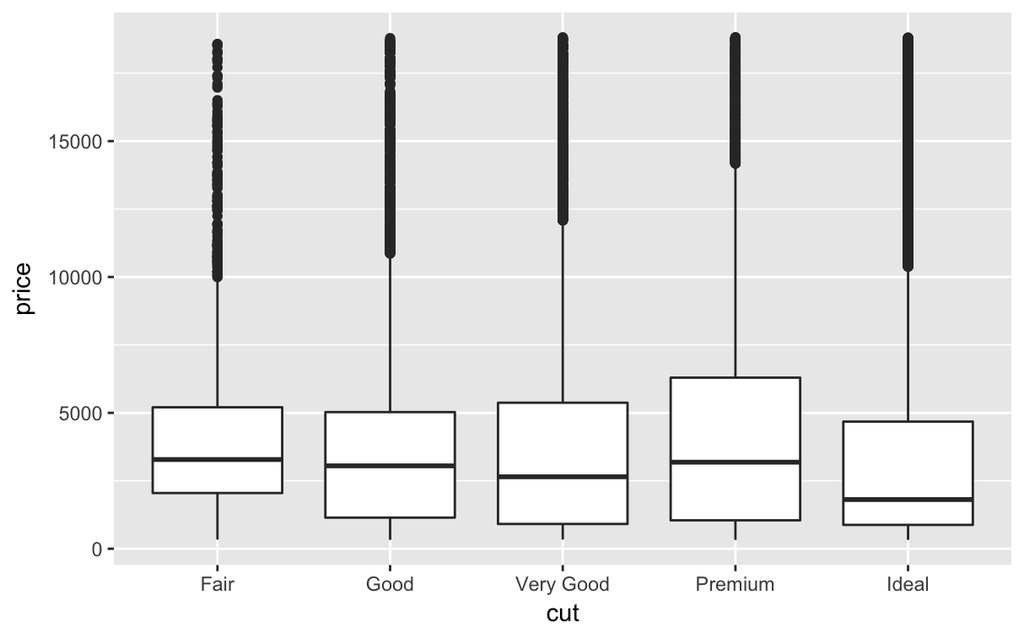

```r
ggplot(data = diamonds, mapping = aes(x = cut, y = price)) +
  geom_boxplot()
```

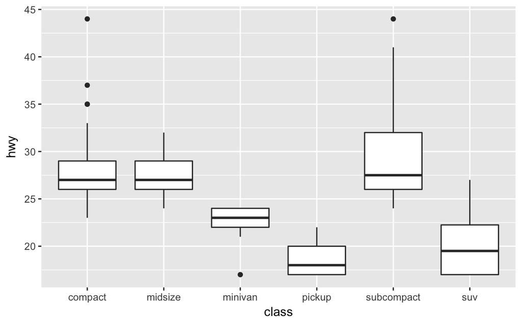

```r
ggplot(data = mpg, mapping = aes(x = class, y = hwy)) +
  geom_boxplot()
```

# order the data

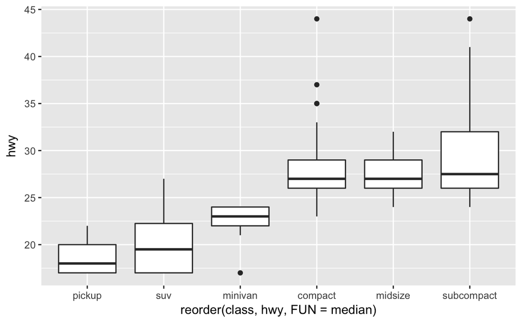

```r
ggplot(data = mpg) +
  geom_boxplot(mapping = aes(x = reorder(class, hwy, FUN = median), y = hwy))
```

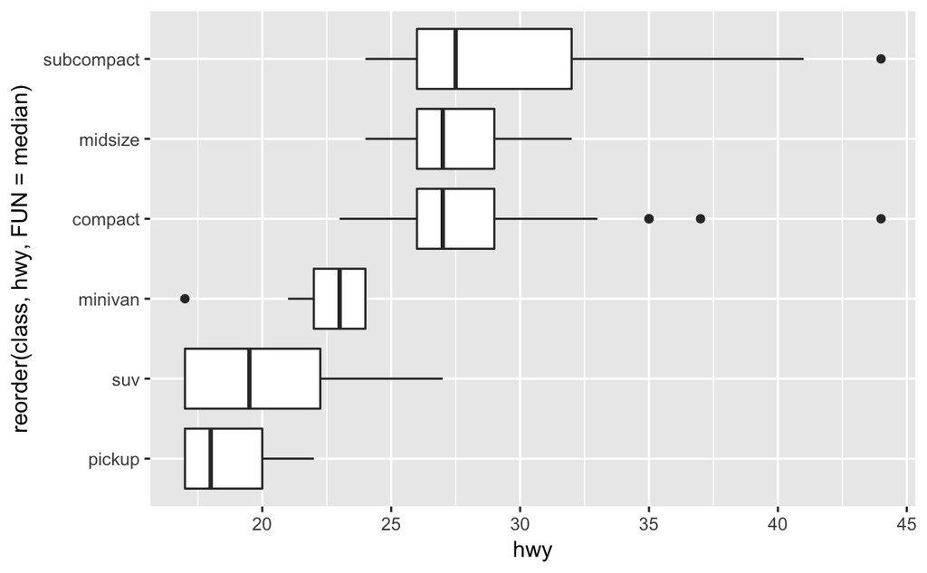

```r
ggplot(data = mpg) +
  geom_boxplot(mapping = aes(x = reorder(class, hwy, FUN = median), y = hwy)) +
  coord_flip()
```